# Math5733-HW7-NataliaVillegas

```python
import numpy as np
%matplotlib inline
import matplotlib.pyplot as plt
from numpy import linalg as LA
```

## Exercise 4.4

In this exercise we want to study the rate of convergence of the explicit scheme by doing numerical experiments. Define the error by

$$ e_{\Delta}(t_m) = \max\limits_{j=0,\ldots,n+1} |u(x_j,t_m)-v_j^m| $$

We want to estimate the rate of convergence for the scheme at time $t = 1/10$ for the problem considered in Exercise 4.2 (a).

> **(a)** Estimate, using numerical experiments, a such that $e_{\Delta}(l/10) = O((\Delta t)^{\alpha})$ for $\Delta t = (\Delta x)^2/2$.

### Solution:

```python
# Define the data
def f(x):
    # Initial data chosen so that
    # u_l(0)=f(0) and u_r(0) = f(1), e.g., x
    z = 3*np.sin(np.pi*x)+5*np.sin(4*np.pi*x)
    return z

def u_exact(x,t):
    # Exact solution
    u=3*np.exp(-(np.pi)**2*t)*np.sin(np.pi*x)+5*np.exp(-16*(np.pi)**2*t)*np.sin(4*np.pi*x)
    return u

# Define an explicit method

list_n = [49,99,199,399]
list_errors=np.zeros(4)
list_dt=np.zeros(4)
list_dx=np.zeros(4)
count=0

for n in list_n:
    x = np.linspace(0,1,n+2)
    dx = x[1]-x[0]

    A = np.zeros((n,n))
    np.fill_diagonal(A,2)
    A += np.diag(-np.ones(n-1),k=1)
    A += np.diag(-np.ones(n-1),k=-1)
    A *= 1/dx**2

    r = 1./2
    dt = r*dx**2

    v = np.copy(f(x))

    t = 0


    B = np.eye(n)-dt*A

    while t<.1-0.000001:
        v[1:-1] = np.dot(B,v[1:-1]) # <--------- v_{k+1} is now computed
        t += dt # <-------------- now go to t_{k+1}


    list_errors[count]=LA.norm(v-u_exact(x,t), np.inf)
    list_dt[count]=dt

    count += 1

alpha=np.log(list_errors[1::]/list_errors[0:-1])/np.log(list_dt[1::]/list_dt[0:-1])
print alpha
print list_errors
```

```
[ 1.00039415  1.00009849  1.00002467]
[  7.26631754e-04   1.81558707e-04   4.53834800e-05   1.13454820e-05]
```

> **(b)** Repeat the experiments in (a) using $\Delta t = (\Delta x)^2/6$.

### Solution:

```python
# Define the data
def f(x):
    # Initial data chosen so that
    # u_l(0)=f(0) and u_r(0) = f(1), e.g., x
    z = 3*np.sin(np.pi*x)+5*np.sin(4*np.pi*x)
    return z

def u_exact(x,t):
    # Exact solution
    u=3*np.exp(-(np.pi)**2*t)*np.sin(np.pi*x)+5*np.exp(-16*(np.pi)**2*t)*np.sin(4*np.pi*x)
    return u

# Define an explicit method

list_n = [49,99,199,399]
list_errors=np.zeros(4)
list_dt=np.zeros(4)
list_dx=np.zeros(4)
count=0

for n in list_n:
    x = np.linspace(0,1,n+2)
    dx = x[1]-x[0]

    A = np.zeros((n,n))
    np.fill_diagonal(A,2)
    A += np.diag(-np.ones(n-1),k=1)
    A += np.diag(-np.ones(n-1),k=-1)
    A *= 1/dx**2

    r = 1./6
    dt = r*dx**2

    v = np.copy(f(x))

    t = 0


    B = np.eye(n)-dt*A

    while t<.1-0.000001:
        v[1:-1] = np.dot(B,v[1:-1]) # <--------- v_{k+1} is now computed
        t += dt # <-------------- now go to t_{k+1}

    list_errors[count]=LA.norm(v-u_exact(x,t), np.inf)
    list_dt[count]=dt

    count += 1

alpha=np.log(list_errors[1::]/list_errors[0:-1])/np.log(list_dt[1::]/list_dt[0:-1])
print alpha
print list_errors
```

```
[ 2.00019982  1.99957757  1.74121076]
[  3.18617026e-08   1.99080485e-09   1.24498190e-10   1.11390897e-11]
```

> **(c)** Try to explain the difference in the rate of convergence encountered in the two cases above. Hint: Consider the truncation error discussed in Exercise 4.15 below.

### Solution:

The rate of convergence in the first case is 1. The rate of convergence in the second case is 2, but it decreases as $n$ increases. What is happening is that in the second case we are getting error because of the floating points. There is a maximum of decimals that the computer can process. If we decrease $r$ even more, we are not going to get better results because the computer cannot be more accurate.

## Exercise 4.6

Derive an explicit scheme for the following Neumann problem:

$$ \begin{array}{ll} u_t = u_{xx} &,\mbox{ for $x\in(0,1)$, $t>0$} \\ \ u(x,0)=f(x) &,\mbox{ $x\in(0,1)$} \end{array} $$

Use the analytical solution given in Example 3.5 on page 101 to check the quality of your approximations.

### Solution:

$$u_t = u_{xx}\\ (v_t)_j \approx (v_{j-1}-2v_j+v_{j+1})/\Delta x^2 $$

Using the boundary conditions we know that $v_1=v_{-1}$ we do some algebra and we get: $$v^{m+1}=(I-rA)v^m$$ where $$ A= \left( \begin{array}{ccccccc} 2 & -2 & 0 & \cdots & 0 \\ -1 & 2 & -1 & \ddots & \vdots \\ 0 & \ddots & \ddots & \ddots & 0 \\ \vdots & \ddots & -1 & 2 & -1 \\ 0 & \cdots & 0 & -2 & 2 \end{array} \right). \ $$

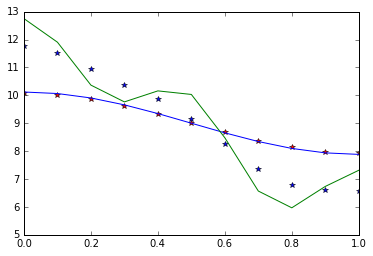

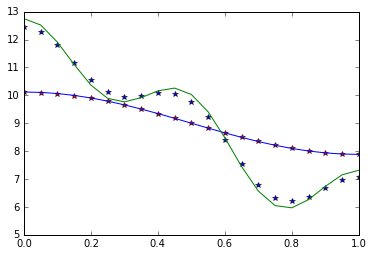

```python
# Define the data
def f(x):
    z = 9+ 3*np.cos(np.pi*x)+5*np.cos(4*np.pi*x)
    return z

def u_exact(x,t):
    # Exact solution
    u=9+3*np.exp(-(np.pi)**2*t)*np.cos(np.pi*x)+5*np.exp(-16*(np.pi)**2*t)*np.cos(4*np.pi*x)
    return u

# Define an explicit method

list_n = [9,19]
i=1
for n in list_n:
    x = np.linspace(0,1,n+2)
    dx = x[1]-x[0]
    A = np.zeros((n+2,n+2))
    np.fill_diagonal(A,2)
    A += np.diag(-np.ones(n+1),k=1)
    A += np.diag(-np.ones(n+1),k=-1)
    A[0,1] = -2
    A[n+1,n] = -2
    A *= 1/dx**2

    r = 0.49
    dt = r*dx**2

    t = 0
    B = np.eye(n+2)-dt*A

    v1 = np.copy(f(x))
    T1 = 0.1
    while t<T1:
        v1 = np.dot(B,v1)
        t += dt

    t = 0
    v2 = np.copy(f(x))
    T2 = 0.01
    while t<T2:
        v2 = np.dot(B,v2)
        t += dt

    plt.figure(i)
    plt.plot(x,v1,'r*',x,u_exact(x,T1),x,v2,'b*',x,u_exact(x,T2))
    i+=i
```

## Exercise 4.7

Repeat Exercise 4.6 by deriving an implicit approximation of the problem. Compare the numerical solutions provided by the explicit and the implicit schemes.

### Solution:

By 4.6 we know that $v^{m+1}=(I-rA)v^m.$ Then,

$$v^{m+1}-v^m=-rAv^{m+1}\\ (I+rA)v^m+1=v^m\\ v^{m+1}=(I+rA)^{-1}v^m $$

where $$ A= \left( \begin{array}{ccccccc} 2 & -2 & 0 & \cdots & 0 \\ -1 & 2 & -1 & \ddots & \vdots \\ 0 & \ddots & \ddots & \ddots & 0 \\ \vdots & \ddots & -1 & 2 & -1 \\ 0 & \cdots & 0 & -2 & 2 \end{array} \right). \ $$

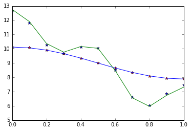

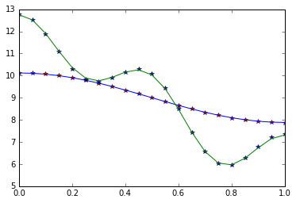

```python
# Define an implicit method

list_n = [9,19]
i=1
for n in list_n:
    x = np.linspace(0,1,n+2)
    dx = x[1]-x[0]

    A = np.zeros((n+2,n+2))
    np.fill_diagonal(A,2)
    A += np.diag(-np.ones(n+1),k=1)
    A += np.diag(-np.ones(n+1),k=-1)
    A[0,1] = -2
    A[n+1,n] = -2
    A *= 1/dx**2

    r = 0.49
    dt = r*dx**2

    v = np.copy(f(x))

    B = np.eye(n+2)+dt*A
    B_inv = np.linalg.inv( B )

    t=0
    v1 = np.copy(f(x))
    T1 = 0.1
    while t<T1:
        t += dt
        v1 = np.dot(B_inv,v1)

    t = 0
    v2 = np.copy(f(x))
    T2 = 0.01
    while t<T2:
        t += dt
        v2 = np.dot(B_inv,v2)


    plt.figure(i)
    plt.plot(x,v1,'r*',x,u_exact(x,T1),x,v2,'b*',x,u_exact(x,T2))
    i+=i
```

## Exercise 4.11

Consider the problem

$$ \begin{array}{ll} u_t = (\alpha(x,t)u_x)_x + c(x,t)u_x + q(x,t)u &,\mbox{ for $x\in(\ell_1,\ell_2)$, $t>0$} \\ u_x(\ell_1,t)=a(t),\quad u_x(\ell_2,t)=b(t), \\ u(x,0)=f(x) \quad,\mbox{ $x\in(\ell_1,\ell_2)$} \end{array} $$

where $\ell_2 > \ell_1$ are given constants, and $a(t),b(t),a(x,t),c(x,t)$, and $q(x,t)$ are given functions.

> **(a)** Derive an explicit scheme.

### Solution:

Let $$u_t = (\alpha(x,t)u_x)_x + c(x,t)u_x + q(x,t)u ,\mbox{ for $x\in(\ell_1,\ell_2)$, $t>0$}. $$

By Exercise 4.20, we know that $$ (\alpha(x,t)u_x)_x = \frac{\alpha_{j+1/2}^{m}(v_{j+1}^m-v_{j}^m)-\alpha_{j-1/2}^{m}(v_{j}^m-v_{j-1}^m)}{\Delta x^2} $$ where $\alpha_{j+1/2}^{m}=(\alpha(v_{j+1}^{m})+\alpha(v_{j}^{m}))/2.$

By C.F.D, we know that $$ c(x,t)u_x=c_j\frac{v_{j+1}-v_{j-1}}{2\Delta x}.$$

Then, $$(v_t)_j =\frac{\alpha_{j+1/2}(v_{j+1}-v_{j})-\alpha_{j-1/2}(v_{j}-v_{j-1})}{\Delta x^2} + c_j\frac{v_{j+1}-v_{j-1}}{2\Delta x} + q(x,t)u\\ (v_t)_j =v_{j+1}\frac{\alpha_{j+1/2}}{\Delta x^2} -v_{j}(\frac{-\alpha_{j-1/2}}{\Delta x^2}+\frac{-\alpha_{j+1/2}}{\Delta x^2})+ v_{j-1}\frac{\alpha_{j-1/2}}{\Delta x^2} + c_j\frac{v_{j+1}-v_{j-1}}{2\Delta x} + q(x,t)v_j\\ $$

By the boundary conditions, we know that $$u_x(\ell_1,t)=a(t),\quad u_x(\ell_2,t)=b(t), $$ Then, $v_{-1}=-2\Delta x a + v_1$ and $v_{j+2}=2\Delta x b + v_j$

If we evaluate $j=0$, we get: $$ (v_t)_0 =v_{1}\frac{\alpha_{1/2}}{\Delta x^2} -v_{0}(\frac{-\alpha_{-1/2}}{\Delta x^2}+\frac{-\alpha_{1/2}}{\Delta x^2})+ v_{-1}\frac{\alpha_{-1/2}}{\Delta x^2} + c_j\frac{v_{1}-v_{-1}}{2\Delta x} + q(x,t)v_j\\ $$ After plug $v_{-1}=-2\Delta x a + v_1$ and doing some algebra we get: $$ v_0^{m+1}=v_1^m(\frac{\alpha_{1/2}}{\Delta x^2}+\frac{\alpha_{-1/2}}{\Delta x^2})\Delta t - v_0^m(\frac{\alpha_{1/2}}{\Delta x^2}+\frac{\alpha_{-1/2}}{\Delta x^2}-q+1/\Delta t)\Delta t - 2\Delta x a \frac{\alpha_{-1/2}}{\Delta x^2}\Delta t $$ We do a similar process for the right boundary.

> **(b)** Derive an implicit scheme.

### Solution:

Let $$u_t = (\alpha(x,t)u_x)_x + c(x,t)u_x + q(x,t)u ,\mbox{ for $x\in(\ell_1,\ell_2)$, $t>0$}. $$

By Exercise 4.20, we know that $$ (\alpha(x,t)u_x)_x = \frac{\alpha_{j+1/2}^{m}(v_{j+1}^m-v_{j}^m)-\alpha_{j-1/2}^{m}(v_{j}^m-v_{j-1}^m)}{\Delta x^2} $$ where $\alpha_{j+1/2}^{m}=(\alpha(v_{j+1}^{m})+\alpha(v_{j}^{m}))/2.$

By C.F.D, we know that $$ c(x,t)u_x=c_j\frac{v_{j+1}-v_{j-1}}{2\Delta x}.$$

Then, $$(v_t)_j =\frac{\alpha_{j+1/2}^{m+1}(v_{j+1}^{m+1}-v_{j}^{m+1})-\alpha_{j-1/2}^{m+1}(v_{j}^{m+1}-v_{j-1}^{m+1})}{\Delta x^2} + c_j\frac{v_{j+1}^{m+1}-v_{j-1}^{m+1}}{2\Delta x} + q(x,t)v_j^{m+1}\\ v_j^m=v_j^{m+1}(1+\frac{\Delta t \alpha_{j+1/2}^{m+1}}{\Delta x^2}-\Delta t q - \frac{\Delta t \alpha_{j-1/2}^{m+1}}{\Delta x^2}) + v_{j+1}^{m+1}(\frac{\Delta t \alpha_{j+1/2}^{m+1}}{\Delta x^2}-\Delta t c) + v_{j-1}^{m+1}(-\frac{\Delta t \alpha_{j-1/2}^{m+1}}{\Delta x^2}+c\Delta t) $$

By the boundary conditions, we know that $$u_x(\ell_1,t)=a(t),\quad u_x(\ell_2,t)=b(t), $$ Then, $v_{-1}=-2\Delta x a + v_1$ and $v_{j+2}=2\Delta x b + v_j$

when j=0: $$ v_0^{m+1}=v_1^m(\frac{\alpha_{1/2}}{\Delta x^2}+\frac{\alpha_{-1/2}}{\Delta x^2})\Delta t - v_0^m(\frac{\alpha_{1/2}}{\Delta x^2}+\frac{\alpha_{-1/2}}{\Delta x^2}-q+1/\Delta t)\Delta t - 2\Delta x a \frac{\alpha_{-1/2}}{\Delta x^2}\Delta t $$

For the right boundary (j+1):

$$v_{j+1}^m=v_j^{m+1}(1+\frac{\Delta t \alpha_{j+1/2}^{m+1}}{\Delta x^2}-\Delta t q - \frac{\Delta t \alpha_{j-1/2}^{m+1}}{\Delta x^2}) + v_{j}^{m+1}(\frac{\Delta t \alpha_{j+1/2}^{m+1}}{\Delta x^2}-\Delta t c) + v_{j}^{m+1}(-\frac{\Delta t \alpha_{j-1/2}^{m+1}}{\Delta x^2}+c\Delta t) $$

## Exercise 4.16

Motivated by the result of Exercise 4.15, we study, in this exercise, the difference scheme 4.49 with $\theta = 1/2$. This difference scheme is usually referred to as the Crank-Nicholson scheme. In component form the scheme is given by

$$ \frac{v_j^{m+1}-v_j^m}{\Delta t} = \frac{1}{2}\Big(\frac{v_{j-1}^{m+1}-2v_{j}^{m+1}+v_{j+1}^{m+1}}{\Delta x^2} + \frac{v_{j-1}^{m}-2v_{j}^{m}+v_{j+1}^{m}}{\Delta x^2}\Big) $$

for $j = 1, 2 , \ldots , n$ and $m \geq 0$.

**(Skip part (a))**

> **(b)** Discuss how the vectors $v^{m+1} \in \mathbb{R}^n$ can be computed from $v^m$.

### Solution:

$$ \frac{v_j^{m+1}-v_j^m}{\Delta t} = \frac{1}{2}\Big(\frac{v_{j-1}^{m+1}-2v_{j}^{m+1}+v_{j+1}^{m+1}}{\Delta x^2} + \frac{v_{j-1}^{m}-2v_{j}^{m}+v_{j+1}^{m}}{\Delta x^2}\Big) $$

for $j = 1, 2 , \ldots , n$ and $m \geq 0$. Let $$\vec{v}^{m+1}=(v_1^{m+1},v_2^{m+1},...,v_n^{m+1})$$ $$\vec{v}^{m+1}-\vec{v}^{m}=\frac{\delta t}{2}(-A\vec{v}^{m+1}-A\vec{v}^m$)$$ Where $A$ is the matrix we have been working on. Then, $$(I+\frac{\Delta t}{2}A)\vec{v}^{m+1}=(I-\frac{\Delta t}{2}A)\vec{v}^m\\ \vec{v}^{m+1}=(I+\frac{\Delta t}{2}A)^{-1}(I-\frac{\Delta t}{2}A)\vec{v}^m$$

> **(c)** Show that the solution of the Crank-Nicholson scheme for the initialboundary value problem (4.1) admits the representation $$ v_j^m = \sum\limits_{k=1}^{n} \gamma_k(\alpha(\mu_k))^m \sin(k\pi x_j), $$ where $\alpha(\mu) = (1-\frac{\Delta t}{2}\mu)(1+\frac{\Delta t}{2}\mu)^{-1}$ and $\gamma_k = 2\Delta x \sum_{j=1}^{n} v_j^0 \sin(k\pi x_j)$.

### Solution:

By part (b) we know that $$\vec{v}^{m+1}=(I+\frac{\Delta t}{2}A)^{-1}(I-\frac{\Delta t}{2}A)\vec{v}^m.$$ Then, if we evaluate at $m=0$, we get: $$\vec{v}^{1}=(I+\frac{\Delta t}{2}A)^{-1}(I-\frac{\Delta t}{2}A)\vec{v}^0.$$ If we evaluate at $m=1$, we get: $$\vec{v}^{2}=((I+\frac{\Delta t}{2}A)^{-1}(I-\frac{\Delta t}{2}A))^2\vec{v}^0.$$ If we continue doing this process we get: $$\vec{v}^{m=1}=((I+\frac{\Delta t}{2}A)^{-1}(I-\frac{\Delta t}{2}A))^{m+1}\vec{v}^0.$$

By Project 3.1, we know that $$v_j^{m}=\sum_{k=1}^n c_k((1-\frac{\Delta t}{2}\mu)(1+\frac{\Delta t}{2}\mu)^{-1})^m sin(k\pi x_j)$$

where $c_k=2\Delta x\sum_{j=1}^n v_j^0 sin(k\pi x_j)$ by Exercise 2.29.

Therefore, $$ v_j^m = \sum\limits_{k=1}^{n} \bigg( \bigg[2\Delta x \sum_{j=1}^{n} v_j^0 \sin(k\pi x_j)\bigg]\big((1-\frac{\Delta t}{2}\mu)(1+\frac{\Delta t}{2}\mu)^{-1}\big)^m \sin(k\pi x_j)\bigg), $$ as desired.

> **(d)** Show that the amplification factor of the difference scheme, $\alpha(\mu)$, satisfies $$ |\alpha(\mu)-e^{-\mu \Delta t}| = O((\Delta t)^3). $$ How does this result relate to the corresponding result for the explicit scheme (4.4)? Compare your result with the conclusions you derived in Exercise 4.15.

### Solution:

Let $\alpha(\mu) = (1-\frac{\Delta t}{2}\mu)(1+\frac{\Delta t}{2}\mu)^{-1}$. Using Taylor expansion for $e^{-\mu \Delta x}$: $$ |\alpha(\mu)-e^{-\mu \Delta t}| = \bigg |(1-\frac{\Delta t}{2}\mu)(1+\frac{\Delta t}{2}\mu)^{-1}-e^{-\mu \Delta t}\bigg|=\bigg|\frac{(1-\frac{\Delta t}{2}\mu)-(1+\frac{\Delta t}{2}\mu)e^{-\mu \Delta t}}{1+\frac{\Delta t}{2}\mu}\bigg|\\ =\bigg|\frac{(1-\frac{\Delta t}{2}\mu)-(1+\frac{\Delta t}{2}\mu)\bigg[1+(-\mu \Delta t)+\frac{1}{2}(-\mu \Delta t)^2+\frac{1}{6}(-\mu \Delta t)^3+O((-\mu \Delta t)^4)\bigg]}{1+\frac{\Delta t}{2}\mu}\bigg|\\ = O((\Delta t)^3). $$

Then, we have shown that by combining explicit and implicit scheme we increse our rate of convergence from $O((\Delta t))+O((\Delta x)^2)$ to $O((\Delta t)^3).$

> **(e)** Implement the Crank-Nicholson scheme. Choose the initial function $f(x)$ as in Example 4.2 and try to verify that the scheme is unconditionally stable by varying the parameter $r = \frac{\Delta t}{(\Delta x)^2}$.

### Solution:

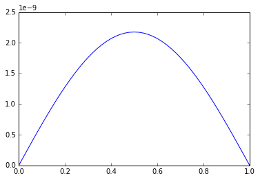

```python
# Define the data

def f(x):
    n = np.size(x)
    z = np.zeros(n)
    for i in xrange(0,n):
        if 0 <= x[i] and x[i] <= 0.5:
            z[i] = 2*x[i]

        elif 0.5 <= x[i] and x[i] <= 1:
            z[i] = 2*(1-x[i])
    return z


# Define an explicit method

n = 49
x = np.linspace(0,1,n+2)
dx = x[1]-x[0]

A = np.zeros((n,n))
np.fill_diagonal(A,2)
A += np.diag(-np.ones(n-1),k=1)
A += np.diag(-np.ones(n-1),k=-1)
A *= 1/dx**2

r = 0.49
dt = r*dx**2

v = np.copy(f(x))

t = 0



B1 = np.eye(n)+dt*A
B2 = np.eye(n)-dt*A
B1_inv = np.linalg.inv( B1 )
B=np.dot( B1_inv, B2 )


while t<1:
    v[1:-1] = np.dot(B,v[1:-1])
    t += dt

plt.plot(x,v)
```

## 4.20

The purpose of this exercise is to derive a finite difference scheme for the following problem:

$$ \begin{array}{ll} u_t = (\alpha(u)u_x)_x &,\mbox{ for $x\in(0,1)$, $t>0$} \\ u_x(0,t)=u_x(1,t)=0 &,\mbox{ $t>0$} \\ u(x,0)=f(x) \quad,\mbox{ $x\in(0,1)$} \end{array} $$

where $\alpha(u)$ is a given strictly positive and smooth function.

> **(a)** Put $v = \alpha(u)u_x$ and justify the following approximations: $$ \begin{array}{ll} u_t(x,t) \approx \frac{u(x,t+\Delta t)-u(x,t)}{\Delta t}, \\ v_x(x,t) \approx \frac{v(x+\Delta x/2,t)-v(x-\Delta x/2,t)}{\Delta x} \end{array} $$

### Solution:

Let $v = \alpha(u)u_x.$ By the central difference derivative: $$ v(x+ \Delta x/2,t) = v(x,t) +\Delta x/2 v_{x}(x,t) + \frac{\Delta x^2}{8} v_{xx}(x,t) + O(\Delta x^3)\\ v(x- \Delta x/2,t) = v(x,t) -\Delta x/2 v_{x}(x,t) + \frac{\Delta x^2}{8} v_{xx}(x,t) - O(\Delta x^3)\\ v(x+\Delta x/2,t) - v(x - \Delta x/2,t) = \Delta x v_{x}(x,t) + O(\Delta x^3)\\ \frac{v(x+\Delta x/2,t) - v(x - \Delta x/2,t)}{\Delta x} = v_{x}(x,t) + O(\Delta x^2) $$ by the forward difference method: $$u_t(x,t)=\frac{u(x,t+\Delta t)-u(x,t)}{\Delta t}+O(\Delta t)$$

> **(b)** Show that $$ v(x+\Delta x/2,t) \approx \frac{1}{2}(\alpha(u(x+\Delta x,t))+\alpha(u(x,t)))\frac{u(x+\Delta x,t)-u(x,t)}{\Delta x} $$

### Solution:

By the central difference approximation: $$ u_{x}(x+\Delta x/2,t) \approx \frac{u(x+\Delta x,t) - u(x,t)}{\Delta x}. $$ And $\alpha (u)$ is a strictly positive and smooth function, then $$ \alpha(u (x + \Delta x/2,t)) \approx \frac{1}{2}(\alpha(u(x + \Delta x,t)) + \alpha(u(x,t)). $$

Let $v = \alpha(u)u_x$. Then, $$v(x+ \Delta x/2,t) = \alpha(u(x+ \Delta x/2,t))u_x(x+ \Delta x/2,t)\\ v(x+ \Delta x/2,t)\approx \frac{1}{2}(\alpha(u(x + \Delta x,t)) + \alpha(u(x,t))\frac{u(x+\Delta x,t) - u(x,t)}{\Delta x}$$

> **(c)** Use these approximations to derive the scheme $$ \frac{v_j^{m+1}-v_j^m}{\Delta t} = \frac{\alpha_{j+1/2}^{m}(v_{j+1}^m-v_{j}^m)-\alpha_{j-1/2}^{m}(v_{j}^m-v_{j-1}^m)}{\Delta x^2} $$ where $\alpha_{j+1/2}^{m}=(\alpha(v_{j+1}^{m})+\alpha(v_{j}^{m}))/2$

### Solution:

Let $$ u_t = (\alpha(u)u_x)_x ,\mbox{ for $x\in(0,1)$, $t>0$} $$ By part (a) we know that: $$v_x(x,t) \approx \frac{v(x+\Delta x/2,t)-v(x-\Delta x/2,t)}{\Delta x}$$ By part (b) we know that: $$ v(x+\Delta x/2,t) \approx \frac{1}{2}(\alpha(u(x+\Delta x,t))+\alpha(u(x,t)))\frac{u(x+\Delta x,t)-u(x,t)}{\Delta x} $$ Then, $$v_x(x,t) \approx \frac{\frac{1}{2}(\alpha(u(x+\Delta x,t))+\alpha(u(x,t)))\frac{u(x+\Delta x,t)-u(x,t)}{\Delta x}-\frac{1}{2}(\alpha(u(x-\Delta x,t))+\alpha(u(x,t)))\frac{u(x-\Delta x,t)-u(x,t)}{\Delta x}}{\Delta x}\\ v_{x} = \frac{ \alpha_{j+1/2}(u(x+\Delta x,t) -u(x,t)- \alpha_{j-1/2}(u(x,t) - u(x-\Delta x,t)}{\Delta x^2}\\ \frac{v_j^{m+1}-v_j^m}{\Delta t} = \frac{\alpha_{j+1/2}^{m}(v_{j+1}^m-v_{j}^m)-\alpha_{j-1/2}^{m}(v_{j}^m-v_{j-1}^m)}{\Delta x^2} $$ where $\alpha_{j+1/2}^{m}=(\alpha(v_{j+1}^{m})+\alpha(v_{j}^{m}))/2$